The try-it-yourself-version: https://mybinder.org/v2/gh/MaraAcuja/news_search/c72714830d958d50513902a4bd6b494122865793?urlpath=lab%2Ftree%2Fnews_search.ipynb

```python
!pip install bs4
!pip install nltk
!pip install wordcloud
!pip install cufflinks
!pip3 install newspaper3k
!pip install textblob
!pip install HanTa
!pip install plotly jupyterlab
```

# News reader by Matthias Kunz

This notebook contains the code to scrape different news pages to build a recommender system based on a user specified question. The system is built for usage of german language and german news pages.

## Data acquisition

At first, the news articles have to be scraped. Unfortunately, some of the newspapers or news agencies do not offer a complete list of news articles. And also the main website of some is not supported by newspaper3k. Therefore a small trick is done. Using the google news website, a search for articles of a specified newspaper is done. The search is done on a interval but the search interval can be freely chosen. In this example only german articles are searched.

The search returns an xml including all the links to the articles and the publishing dates. Afterwards, the newspaper package is used to download also the title and the content of the article. Invalid links are excluded.

```python
# imports
from dateutil.rrule import *
from datetime import *
from newspaper import Article, ArticleException
import nltk
nltk.download('punkt')
from bs4 import BeautifulSoup
import requests
import pandas as pd
```

```python
# defining the timeframe from when the news pages should be gathered
# monthly base but not fine enough for daily newspapers ~30 articles / day -> 300/month but google just gets 100
start_dates = [datetime.strftime(dt, "%Y-%m-%d") for dt in rrule(MONTHLY, dtstart=datetime(2022, 1, 1), until=datetime(2022, 6, 1))]
end_dates = [datetime.strftime(dt, "%Y-%m-%d") for dt in rrule(MONTHLY, dtstart=datetime(2022, 1, 31), bymonthday=(31, -1), bysetpos=1, until=datetime(2022, 6, 30))]

# daily base
#start_dates = [datetime.strftime(dt, "%Y-%m-%d") for dt in rrule(DAILY, dtstart=datetime(2022, 1, 1), until=datetime(2022, 1, 10))]
#end_dates = [datetime.strftime(dt, "%Y-%m-%d") for dt in rrule(DAILY, dtstart=datetime(2022, 1, 2), until=datetime(2022, 1, 11))]
dates_list = list(zip(start_dates, end_dates))
dates_list
```

```
[('2022-01-01', '2022-01-31'),
 ('2022-02-01', '2022-02-28'),
 ('2022-03-01', '2022-03-31'),
 ('2022-04-01', '2022-04-30'),
 ('2022-05-01', '2022-05-31'),
 ('2022-06-01', '2022-06-30')]
```

```python
# get articles from news pages; inspired by https://blog.finxter.com/analyzing-news-articles-with-newspaper3k-textblob-and-seaborn/ for data acquisition

def get_articles(dates):
    news_sites = ['faz.net', 'dw.com', 'sueddeutsche.de', 'taz.de', 'nzz.ch']
    data = []
    article_titles = []
    article_contents = []
    article_urls = []
    article_pubdate = []
    counter = 0

    for site in news_sites:
        print(site)
        # loop through single months to get the urls from a search in google news
        for date1, date2 in dates:
            print("Gets urls from " + str(date1) + "...")

            # URL of the Google News RSS with Joe Biden in the search parameter
            main_url = "https://news.google.com/rss/search?q=after:" + date1 + "+before:" + date2 + "+site:" + site + "&ceid=DE:en&hl=de-DE&gl=DE"
            #print(main_url)

            # get the results in the RSS and collect the links
            response = requests.get(main_url)
            webpage = response.content
            soup = BeautifulSoup(webpage, features="xml")
            items = soup.find_all('item')
            for item in items:
                link = item.find('link').text
                article_urls.append(link)
                date = item.find('pubDate').text
                article_pubdate.append(date)
        print("Fetched " + str(len(article_urls)) + " urls.")
        # getting the articles from the news site by calling the gathered url
    for url in article_urls:
        counter +=1
        if counter % 50 == 0:
            print("Processed " + str(counter) + " articles..." )

        # We throw this in a try/except block in case we get a bad link which would kill the program
        try:
        # Newspaper3k to scrape the article text and title
            article = Article(url, language='de')
            article.download()
            article.parse()
            article.nlp()

            article_titles.append(article.title)
            article_contents.append(article.text)

            # If there is a bad link, move on to the next one
        except ArticleException:
            print("There was a bad link: " + url)
            article_titles.append('NaN')
            article_contents.append('NaN')
            pass
    data = {'title': article_titles, 'url': article_urls, 'content': article_contents, 'time': article_pubdate}

    return(pd.DataFrame(data))
```

```python
# get the articles

articles = get_articles(dates_list)
```

```
faz.net
Gets urls from 2022-01-01...
Gets urls from 2022-02-01...
Gets urls from 2022-03-01...
Gets urls from 2022-04-01...
Gets urls from 2022-05-01...
Gets urls from 2022-06-01...
Fetched 600 urls.
dw.com
Gets urls from 2022-01-01...
Gets urls from 2022-02-01...
Gets urls from 2022-03-01...
Gets urls from 2022-04-01...
Gets urls from 2022-05-01...
Gets urls from 2022-06-01...
Fetched 936 urls.
sueddeutsche.de
Gets urls from 2022-01-01...
Gets urls from 2022-02-01...
Gets urls from 2022-03-01...
Gets urls from 2022-04-01...
Gets urls from 2022-05-01...
Gets urls from 2022-06-01...
Fetched 1536 urls.
taz.de
Gets urls from 2022-01-01...
Gets urls from 2022-02-01...
Gets urls from 2022-03-01...
Gets urls from 2022-04-01...
Gets urls from 2022-05-01...
Gets urls from 2022-06-01...
Fetched 1615 urls.
nzz.ch
Gets urls from 2022-01-01...
Gets urls from 2022-02-01...
Gets urls from 2022-03-01...
Gets urls from 2022-04-01...
Gets urls from 2022-05-01...
Gets urls from 2022-06-01...
Fetched 2215 urls.
```

[output cut: 77 more lines]

```
Processed 1500 articles...
Processed 1550 articles...
Processed 1600 articles...
Processed 1650 articles...
Processed 1700 articles...
Processed 1750 articles...
Processed 1800 articles...
Processed 1850 articles...
Processed 1900 articles...
Processed 1950 articles...
Processed 2000 articles...
Processed 2050 articles...
Processed 2100 articles...
Processed 2150 articles...
Processed 2200 articles...
```

Next, the timestamp is changed to a timestamp supported by pandas.

```python
# change the time format to a usual time format

articles['time'] = pd.to_datetime(articles.time, format="%a, %d %b %Y %H:%M:%S GMT")
articles
```

|  | title | url | content | time |
| --- | --- | --- | --- | --- |
| 0 | Ukraine-Konflikt: Die USA legen Russland eigen... | https://www.faz.net/aktuell/politik/ausland/uk... | Nach einem Krisengespräch der Außenminister An... | 2022-01-21 08:00:00 |
| 1 | Putins Optionen: Kommt es zum Krieg mit der Uk... | https://www.faz.net/aktuell/politik/ausland/pu... | Wie es in der Auseinandersetzung zwischen Russ... | 2022-01-19 08:00:00 |
| 2 | Baerbock und Blinken: Entschlossen gegenüber P... | https://www.faz.net/aktuell/politik/ausland/ba... | Außenministerin Annalena Baerbock und der amer... | 2022-01-20 08:00:00 |
| 3 | Joe Bidens Aussage im Ukraine-Konflikt schocki... | https://www.faz.net/aktuell/politik/ausland/jo... | Wegen einer missverständlichen Aussage zum Ukr... | 2022-01-20 08:00:00 |
| 4 | Ukraine-Krise: Plant Russland eine False-Flag-... | https://www.faz.net/aktuell/politik/ausland/uk... | Washington erhebt detaillierte Vorwürfe gegen ... | 2022-01-16 08:00:00 |
| ... | ... | ... | ... | ... |
| 2210 | Die Kommission gibt Kiew grünes Licht für den ... | https://www.nzz.ch/international/unterstuetzun... | Unterstützung für den «europäischen Traum»: Di... | 2022-06-17 07:00:00 |
| 2211 | Russlands Spione in der Schweiz: Die Botschaft... | https://www.nzz.ch/schweiz/russlands-spione-in... | «Die Botschaft dient als Logistikbasis» – so s... | 2022-06-28 07:00:00 |
| 2212 | Drei Gründe, warum in Italien der Populismus i... | https://www.nzz.ch/international/lega-und-cinq... | Lega und Cinque Stelle haben bei den Kommunalw... | 2022-06-29 07:00:00 |
| 2213 | EU-Kandidaten-Status für Ukraine und Moldau al... | https://www.nzz.ch/pro-global/mit-dem-versprec... | Mit dem Versprechen an die Ukraine und die Mol... | 2022-06-29 07:00:00 |
| 2214 | USA Wahlen: Joe Bidens hohes Alter erschreckt ... | https://www.nzz.ch/international/usa-wahlen-jo... | Joe Bidens hohes Alter erschreckt die Demokrat... | 2022-06-29 07:00:00 |

2215 rows × 4 columns

```python
# save data to csv to save computation time

filename = "articles_" + str(start_dates[0]) + "_" + str(end_dates[-1]) + ".csv"
print(filename)
articles.to_csv(filename)
```

```
articles_2022-01-01_2022-06-30.csv
```

```python
# show results

print(articles.iloc[0]['title'])
print("-------------------")
print(articles.iloc[0]['time'])
print("-------------------")
print(articles.iloc[0]['url'])
print("-------------------")
print(articles.iloc[0]['content'])
```

```
Ukraine-Konflikt: Die USA legen Russland eigene Vorschläge vor
-------------------
2022-01-21 08:00:00
-------------------
https://www.faz.net/aktuell/politik/ausland/ukraine-konflikt-die-usa-legen-russland-eigene-vorschlaege-vor-17743972.html
-------------------
Nach einem Krisengespräch der Außenminister Antony Blinken und Sergej Lawrow am Freitag in Genf hat die amerikanische Seite Russland eine schriftliche Antwort auf Moskaus Forderungen angekündigt. Die Vereinigten Staaten würden sich mit ihren Verbündeten abstimmen und dann „einige Vorschläge auf den …

Die Minister hatten ihr Genfer Gespräch am Freitagmittag bereits nach etwa anderthalb Stunden beendet und den geplanten Zeitrahmen damit nicht ganz ausgeschöpft. Von einer Annäherung war danach keine Rede. Lawrow nannte die Unterredung aber „offen und nützlich“. Präsident Wladimir Putin sei auch imm…

Blinken: Beistandspflicht gilt nur für NATO-Staaten

Die Entspannungsbemühungen laufen seit vergangener Woche auf Hochtouren, haben aber bislang keine greifbaren Ergebnisse gebracht. Die Vereinigten Staaten und ihre westlichen Verbündeten verlangen einen Rückzug der an der ukrainischen Grenze zusammengezogenen 100.000 russischen Soldaten ins Hinterlan…

Blinken sagte: „Ich habe die Position der Vereinigten Staaten und unserer europäischen Verbündeten und Partner übermittelt, dass wir fest an der Seite der Ukraine stehen und ihre Souveränität und territoriale Integrität unterstützen“, sagte Blinken. Russland könne mit seiner gegenwärtigen militärisc…

Blinken sagte, er sei sich einig mit Lawrow, dass der diplomatische Prozess fortgesetzt werden müsse. Dass Washington Moskau nächste Woche eine schriftliche Antwort auf die russischen Forderungen geben wolle, bestätigte Blinken. Danach werde man abermals miteinander sprechen.
```

## Preprocessing

In a second step, some preprocessing is done. First, a check for missing values and double rows is performed. Next, we do some text preprocessing like excluding punctuation, invalid words or numbers. The articles are also tokenized and if specified also stemmed. Lastly, the stopwords are removed. Like this, they are in a format to be further processed.

```python
# imports

import re
import nltk
from nltk.tokenize import word_tokenize
from nltk.corpus import stopwords
from nltk.stem import PorterStemmer
from HanTa import HanoverTagger as ht

nltk.download('stopwords')
nltk.download('punkt')
```

```
True
```

```python
# check for doubles or missing values

print(f"number of double rows: {articles.duplicated().sum()}")
print(f"number of missing values:\n{articles.isnull().sum()}")
```

```
number of double rows: 0
number of missing values:
title      0
url        0
content    0
time       0
dtype: int64
```

```python
# preprocessing the content, removing stop words

def preprocess_text(text, stop_words, shouldBeStemmed=False):

    # remove punctuations
    text = text.replace(".", "")

    # tokenize input
    text = word_tokenize(text)

    # exclude "words" without letters (for example numbers)
    text = [word for word in text if re.search('[a-zA-Z]', word)]

    # exclude special characters
    text = [re.sub('[^\w|-|\"|\s]', '', word) for word in text]

    # all lower
    text = [word.lower() for word in text]

    # stemming words for later keyword search
    if shouldBeStemmed:
        ha = ht.HanoverTagger('morphmodel_ger.pgz')
        temp = []
        counter =0
        for word in text:
            temp.append(ha.analyze(word)[0])
        text = temp

    # exclude stopwords
    text = [word for word in text if word not in stop_words]

    return ' '.join(text)
```

```python
# get stop words

stop_words = stopwords.words('german')
print(stop_words[:10]) # example of stop words
```

```
['aber', 'alle', 'allem', 'allen', 'aller', 'alles', 'als', 'also', 'am', 'an']
```

```python
# pre-process data -> apply the above mentioned function on all article bodies

articles['content'] = articles['content'].map(lambda text: preprocess_text(text, stop_words, True)) # pre-process
print(articles.iloc[0]['content'])
```

```
Krisengespräch Außenminister Antony blinken Sergej Lawrow Freitag Genf amerikanisch Seite Russland schriftlich Antwort Moskau Forderung ankündigen vereinigen Staat Verbündet abstimmen Vorschlag Tisch legen sagen blinken Pressekonferenz Amerika Natopartner lehnen strikt russlands Forderung ab Erweite…
```

```python
# save preprocessed data to csv to save computation time

filename = "processed_articles_" + str(start_dates[0]) + "_" + str(end_dates[-1]) + ".csv"
print(filename)
articles.to_csv(filename)

articles
```

```
processed_articles_2022-01-01_2022-06-30.csv
```

|  | title | url | content | time |
| --- | --- | --- | --- | --- |
| 0 | Ukraine-Konflikt: Die USA legen Russland eigen... | https://www.faz.net/aktuell/politik/ausland/uk... | Krisengespräch Außenminister Antony blinken Se... | 2022-01-21 08:00:00 |
| 1 | Putins Optionen: Kommt es zum Krieg mit der Uk... | https://www.faz.net/aktuell/politik/ausland/pu... | Auseinandersetzung Russland Westen weitergehen... | 2022-01-19 08:00:00 |
| 2 | Baerbock und Blinken: Entschlossen gegenüber P... | https://www.faz.net/aktuell/politik/ausland/ba... | Außenministerin Annalena Baerbock amerikanisch... | 2022-01-20 08:00:00 |
| 3 | Joe Bidens Aussage im Ukraine-Konflikt schocki... | https://www.faz.net/aktuell/politik/ausland/jo... | wegen missverständlich Aussage Ukrainekonflikt... | 2022-01-20 08:00:00 |
| 4 | Ukraine-Krise: Plant Russland eine False-Flag-... | https://www.faz.net/aktuell/politik/ausland/uk... | Washington erheben detailliert Vorwurf Moskau ... | 2022-01-16 08:00:00 |
| ... | ... | ... | ... | ... |
| 2210 | Die Kommission gibt Kiew grünes Licht für den ... | https://www.nzz.ch/international/unterstuetzun... | Unterstützung europäisch Traum Kommission gebe... | 2022-06-17 07:00:00 |
| 2211 | Russlands Spione in der Schweiz: Die Botschaft... | https://www.nzz.ch/schweiz/russlands-spione-in... | Botschaft dienen Logistikbasis spionieren Russ... | 2022-06-28 07:00:00 |
| 2212 | Drei Gründe, warum in Italien der Populismus i... | https://www.nzz.ch/international/lega-und-cinq... | Lega Cinque Stelle Kommunalwahl Italien misera... | 2022-06-29 07:00:00 |
| 2213 | EU-Kandidaten-Status für Ukraine und Moldau al... | https://www.nzz.ch/pro-global/mit-dem-versprec... | Versprechen Ukraine Moldau positionieren Eu ge... | 2022-06-29 07:00:00 |
| 2214 | USA Wahlen: Joe Bidens hohes Alter erschreckt ... | https://www.nzz.ch/international/usa-wahlen-jo... | Joe bidens hoch Alter erschrecken Demokrat alt... | 2022-06-29 07:00:00 |

2215 rows × 4 columns

## Data Exploration

In a third step, the data exploration is done. At first, a word cloud is shown. Afterwards, the 25 most often appearing unigrams, bigrams and trigrams are plotted.

```python
# imports

from wordcloud import WordCloud
from sklearn.feature_extraction.text import CountVectorizer
import cufflinks as cf

cf.go_offline()
cf.set_config_file(offline=False, world_readable=True)
```

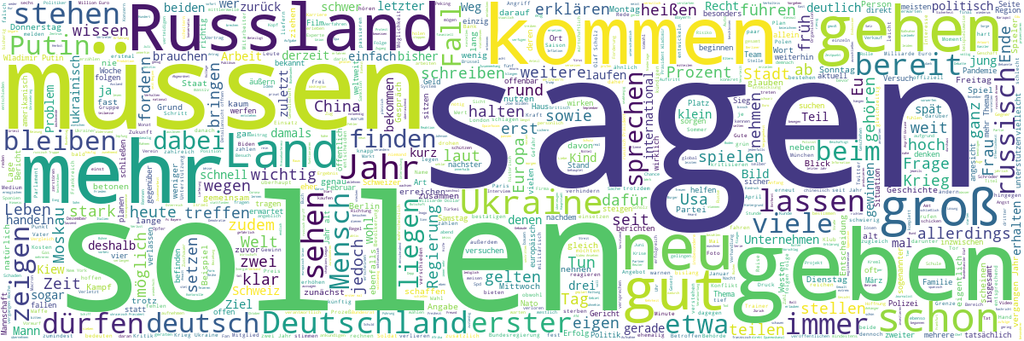

```python
# create wordcloud

all_content = ' '.join(list(articles['content'].values))

wordcloud = WordCloud(width=1200, height=400,
                      background_color="white", max_words=7000,
                      contour_width=3, contour_color='steelblue')
wordcloud.generate(all_content)
wordcloud.to_image()
```

In the wordcloud, one can see that most of the frequent words are german verbs, like "sagen", "gehen", "kommen" and "geben". But also auxiliary verbs, like "müssen" and "sollen". Depending on the happenings of the time period also the major political events can be seen. For the first half year of 2022, the words "Russland", "Ukraine", "Moskau", "Putin" and "russisch" refer to the russian invasion in February 2022 and the ongoing war.

```python
# get top ngrams

def get_ngrams(n, data):
    count_vec = CountVectorizer(ngram_range=(n,n))
    count_data = count_vec.fit_transform(data['content'])
    count_values = count_data.toarray().sum(axis=0)

    vocs = count_vec.vocabulary_
    df_ngram_counts = pd.DataFrame([(count_values[i],k) for k,i in vocs.items()])

    df_ngram_counts = df_ngram_counts.rename(columns={0: 'count', 1: 'bigram'})
    return df_ngram_counts.groupby('bigram').sum().sort_values('count', ascending=False)
```

```python
# visualize top unigrams

get_ngrams(1, articles).head(25).iplot(kind='bar', yTitle='Count', linecolor='black', title='Top 25 Unigrams')
```

[interactive chart not shown]

```python
# visualize top bigrams

get_ngrams(2, articles).head(25).iplot(kind='bar', yTitle='Count', linecolor='black', title='Top 25 Bigrams')
```

[interactive chart not shown]

```python
# visualize top trigrams

get_ngrams(3, articles).head(25).iplot(kind='bar', yTitle='Count', linecolor='black', title='Top 25 Trigrams')
```

[interactive chart not shown]

While the unigrams mainly show the results from the wordclouds like the auxilary verbs, the bi- and trigrams show more contextual information like the main leaders in world politcs or important topics.

## Keyword search

In a fourth step, an application is included into the data science workflow. A keyword search should be performed. Therefore, a user defined sentence or a question is stated. The tokens in the text bodies are characterized by the tfidf-algorithm to get the relative importance of the tokens for the texts. Also the user defined sentence is analyzed using the same model. In a last step, the cosine similarity between the vector for the questions and all the vectors for the articles is calculated and the result are descendingly ordered printed. The most relevant answers for the question are then presented to the user and the user can read the specific answer to get the article for his question.

```python
# Starting with the CountVectorizer/TfidfTransformer approach...

from sklearn.feature_extraction.text import CountVectorizer
from sklearn.feature_extraction.text import TfidfTransformer, TfidfVectorizer
from sklearn.metrics.pairwise import cosine_similarity
import numpy as np


#cvec = CountVectorizer(stop_words=stop_words, min_df=0.005, max_df=.1, ngram_range=(1,2))
cvec = TfidfVectorizer(analyzer='word', ngram_range=(1, 1), min_df = 0.005, stop_words=stop_words)
```

```python
# Calculate all the n-grams found in all documents

from itertools import islice
cvec.fit(articles['content'])
tfidf_matrix = cvec.fit_transform(articles['content'])
list(islice(cvec.vocabulary_.items(), 20))
tfidf_matrix
```

```
<2215x6514 sparse matrix of type '<class 'numpy.float64'>'
	with 400688 stored elements in Compressed Sparse Row format>
```

```python
# Check how many total n-grams we have

len(cvec.vocabulary_)
```

```
6514
```

```python
# tfidf-approach

cvec_counts = cvec.transform(articles.content)
print('sparse matrix shape:', cvec_counts.shape)
print('nonzero count:', cvec_counts.nnz)
print('sparsity: %.2f%%' % (100.0 * cvec_counts.nnz / (cvec_counts.shape[0] * cvec_counts.shape[1])))
```

```
sparse matrix shape: (2215, 6514)
nonzero count: 400688
sparsity: 2.78%
```

```python
# check most common words

occ = np.asarray(cvec_counts.sum(axis=0)).ravel().tolist()
counts_df = pd.DataFrame({'term': cvec.get_feature_names_out(), 'occurrences': occ})
counts_df.sort_values(by='occurrences', ascending=False).head(20)
```

|  | term | occurrences |
| --- | --- | --- |
| 5375 | ukraine | 69.779566 |
| 4545 | sagen | 69.565420 |
| 4514 | russisch | 69.018464 |
| 2912 | jahr | 66.355173 |
| 4843 | sollen | 52.493238 |
| 4515 | russland | 52.159977 |
| 3585 | mehr | 51.024313 |
| 3794 | müssen | 49.266313 |
| 3839 | nan | 48.000000 |
| 2245 | geben | 47.185857 |
| 3880 | neu | 41.947106 |
| 1345 | deutsch | 41.462264 |
| 4252 | prozent | 39.455608 |
| 3307 | land | 39.174998 |
| 2515 | groß | 39.079222 |
| 2545 | gut | 39.031495 |
| 1346 | deutschland | 38.516735 |
| 3609 | mensch | 38.428427 |
| 3138 | kommen | 37.983254 |
| 2296 | gehen | 36.804035 |

```python
# test phrase which we want to find an article about in the collection

phrase = "Eintracht Frankfurt wird den Europapokal gewinnen"
```

```python
# vectorizing the test phrase

matrix2 = cvec.transform([phrase])
matrix2
```

```
<1x6514 sparse matrix of type '<class 'numpy.float64'>'
	with 3 stored elements in Compressed Sparse Row format>
```

```python
# calculating the similarities of the test phrase to the articles

similarity = pd.DataFrame(cosine_similarity(tfidf_matrix, matrix2), columns=['score'])
similarity = similarity.merge(articles, how='outer', left_index=True, right_index=True)
similarity.sort_values(by=['score'], ascending=False)
```

|  | score | title | url | content | time |
| --- | --- | --- | --- | --- | --- |
| 2020 | 0.515495 | Eintracht Frankfurt: Ein Klub verblüfft Fussba... | https://www.nzz.ch/sport/eintracht-frankfurt-f... | wissen nie kommen Eintracht Frankfurt faszinie... | 2022-05-19 07:00:00 |
| 2018 | 0.445906 | Wegen Siegesfeier von Eintracht Frankfurt: Hoc... | https://www.nzz.ch/international/wegen-der-sie... | wegen Siegesfeier Eintracht Frankfurt Hochzeit... | 2022-05-19 07:00:00 |
| 2131 | 0.426402 | Mario Götze: In Frankfurt wagt er einen neuen ... | https://www.nzz.ch/sport/beinahe-ein-weltstar-... | beinahe Weltstar Mario götz Eintracht Frankfur... | 2022-06-22 07:00:00 |
| 75 | 0.425249 | Eintracht Frankfurt: Bei Transfers auf Schnäpp... | https://www.faz.net/aktuell/sport/fussball/bun... | Eintracht Frankfurt müssen sparen deshalb such... | 2022-01-30 08:00:00 |
| 302 | 0.406263 | West Ham gegen Eintracht Frankfurt: London hat... | https://www.faz.net/aktuell/rhein-main/frankfu... | Tausend Anhänger Eintracht Donnerstag London K... | 2022-04-27 07:00:00 |
| ... | ... | ... | ... | ... | ... |
| 811 | 0.000000 | Ermöglicht die EU Bargeldwechsel für geflüchte... | https://www.dw.com/de/erm%C3%B6glicht-die-eu-b... | Laden Restaurant verriegeln Lana bensch frosti... | 2022-04-05 07:00:00 |
| 810 | 0.000000 | Corona: Deutschland lockert - und Lauterbach s... | https://www.dw.com/de/corona-deutschland-locke... | deutsch Gesundheitsminister Karl Lauterbach Sp... | 2022-04-05 07:00:00 |
| 809 | 0.000000 | Netzwerk soll Kultur der Ukraine schützen | https://www.dw.com/de/netzwerk-kulturgutschutz... | neben unermesslich menschlich Leid bedeuten ru... | 2022-04-07 07:00:00 |
| 808 | 0.000000 | Ukraine-Krieg: Deutsche Außenpolitik am Pranger | https://www.dw.com/de/ukraine-krieg-deutsche-a... | Bild Blutbad Zivilist Butscha Vorort Kiew ukra... | 2022-04-08 07:00:00 |
| 2214 | 0.000000 | USA Wahlen: Joe Bidens hohes Alter erschreckt ... | https://www.nzz.ch/international/usa-wahlen-jo... | Joe bidens hoch Alter erschrecken Demokrat alt... | 2022-06-29 07:00:00 |

2215 rows × 5 columns

Above, the results for the cosine similarity are presented. The first two articles are really about the football team from Frankfurt winning the europe league. So for getting correct recommendations a score of above 40% might be sufficient. For other topics like the war in Ukraine "Russland wird die Ukraine angreifen.", it might not be sufficient as sometimes articles are just loosely connected to the war but deal more with the economical consequences in Germany. These wouldn't be good recommendations but also having a quite high similarity.

## Discussion and further approaches

Within this small project, a content-based recommender system for news articles has been developed. After a user wrote a statement or a question, the model recommends the most similiar articles from five different newspapers within a given period of time. The model in general works quite good for some tested examples.

What is missing here, is a real testing setting for the model. It should include some bigger amount of sentences which are proven to be true of false and then an evaluation condition like majority of the first five most relevant articles.

It should be also possible to simplify the model by adding the auxilary verbs, like "können", "sollen", "müssen" and other verbs which carry no relevant information like "sein", "haben", "sagen", "geben" to the list of stop words to exclude them from the model. Further improvement should be done by expanding the stemming to also take synonyms into account. But before, a subject matter expert should answer the question to which amount the simplification should take place. For example, "Russland marschiert in die Ukraine ein" might be something else than "Russland führt Krieg gegen die Ukraine" or "Putin greift die Ukraine an". To some level the three mentioned sentences are synonyms but if we have a stricter view they mean something different.

For deployment there might also be another structure of the project which is faster and cheaper. Like this, all the documents are downloaded at the beginng and then every run again. It would be better to download and then preprocess them once and save them locally in a csv file or similar and just update them.

## Trial version

Enjoy the news search based on reliable journalism!